# Cleaning WVS Data

For example in the relationship between V8 (how important is work) and V9 (how important is religion), we kept V8_1 for V8 and V9_1 for V9 as they both are in the strongest, positive relationship between the two questions. The strongest relationship between the questions overall is between V8_1 and V9_4 (a negative relationship).

The problem is that these questions are related to other questions - we will choose the strongest postivie and negative relationships and then select the single variable to represent the question based on the highest average correlation with the variables from the other questions. After we will ensure that we have not eliminated a variable which was uniquely correlated to one other variable.

```r
#Names of columns to keep in WVS_Data_Precentages5 to keep
VariablestoKeep <- unique(c(Sig_Correlations_Clean[,1],Sig_Correlations_Clean[,2]))
VariablestoKeep_DF <- as.data.frame(VariablestoKeep)
write.csv(VariablestoKeep_DF, "Kendall_Correlation_Var.csv")

str(VariablestoKeep)
```

```
##  chr [1:136] "V9_1_Ref" "V9_3" "V9_4" "V19_1_Ref" "V26_0" "V26_1_Ref" ...
```

```r
WVS_Data_Precentages5_Kendall <- WVS_Data_Precentages5[,VariablestoKeep]

Kendall_PCA <- prcomp(WVS_Data_Precentages5_Kendall)
summary(Kendall_PCA)
```

```
## Importance of components:
##                             PC1     PC2      PC3      PC4      PC5
## Standard deviation     103.3727 47.5887 45.26116 41.05586 36.44179
## Proportion of Variance   0.4062  0.0861  0.07788  0.06408  0.05049
## Cumulative Proportion    0.4062  0.4923  0.57022  0.63430  0.68479
##                             PC6      PC7     PC8     PC9     PC10    PC11
## Standard deviation     33.38419 28.43081 26.9911 26.4530 23.79287 20.3872
## Proportion of Variance  0.04237  0.03073  0.0277  0.0266  0.02152  0.0158
## Cumulative Proportion   0.72716  0.75789  0.7856  0.8122  0.83371  0.8495
##                            PC12     PC13     PC14     PC15     PC16
## Standard deviation     19.51046 18.42745 17.75033 17.02031 16.54712
## Proportion of Variance  0.01447  0.01291  0.01198  0.01101  0.01041
## Cumulative Proportion   0.86398  0.87689  0.88887  0.89988  0.91029
##                            PC17     PC18     PC19     PC20     PC21
## Standard deviation     15.65334 14.94214 13.08586 12.73170 12.05436
## Proportion of Variance  0.00932  0.00849  0.00651  0.00616  0.00552
## Cumulative Proportion   0.91961  0.92809  0.93460  0.94077  0.94629
##                            PC22     PC23     PC24    PC25   PC26    PC27
## Standard deviation     11.71662 11.50341 10.43764 9.53616 9.1677 8.97184
## Proportion of Variance  0.00522  0.00503  0.00414 0.00346 0.0032 0.00306
## Cumulative Proportion   0.95151  0.95654  0.96068 0.96414 0.9673 0.97039
##                           PC28    PC29   PC30    PC31    PC32    PC33
## Standard deviation     8.70242 8.33276 7.7840 7.55412 7.28483 7.14708
## Proportion of Variance 0.00288 0.00264 0.0023 0.00217 0.00202 0.00194
## Cumulative Proportion  0.97327 0.97591 0.9782 0.98039 0.98240 0.98435
##                           PC34    PC35    PC36    PC37    PC38    PC39
## Standard deviation     6.92754 6.24442 6.17111 5.91268 5.46523 5.30191
## Proportion of Variance 0.00182 0.00148 0.00145 0.00133 0.00114 0.00107
## Cumulative Proportion  0.98617 0.98765 0.98910 0.99043 0.99156 0.99263
##                           PC40    PC41    PC42    PC43    PC44    PC45
## Standard deviation     4.91415 4.84150 4.44854 4.33157 3.85543 3.69157
## Proportion of Variance 0.00092 0.00089 0.00075 0.00071 0.00057 0.00052
## Cumulative Proportion  0.99355 0.99444 0.99519 0.99591 0.99647 0.99699
##                          PC46    PC47    PC48    PC49    PC50    PC51
## Standard deviation     3.6258 3.21301 3.13294 3.02394 2.92966 2.75604
## Proportion of Variance 0.0005 0.00039 0.00037 0.00035 0.00033 0.00029
## Cumulative Proportion  0.9975 0.99788 0.99826 0.99860 0.99893 0.99922
##                           PC52    PC53    PC54    PC55      PC56
## Standard deviation     2.50273 2.32350 2.26288 1.93825 4.591e-14
## Proportion of Variance 0.00024 0.00021 0.00019 0.00014 0.000e+00
## Cumulative Proportion  0.99946 0.99966 0.99986 1.00000 1.000e+00
```

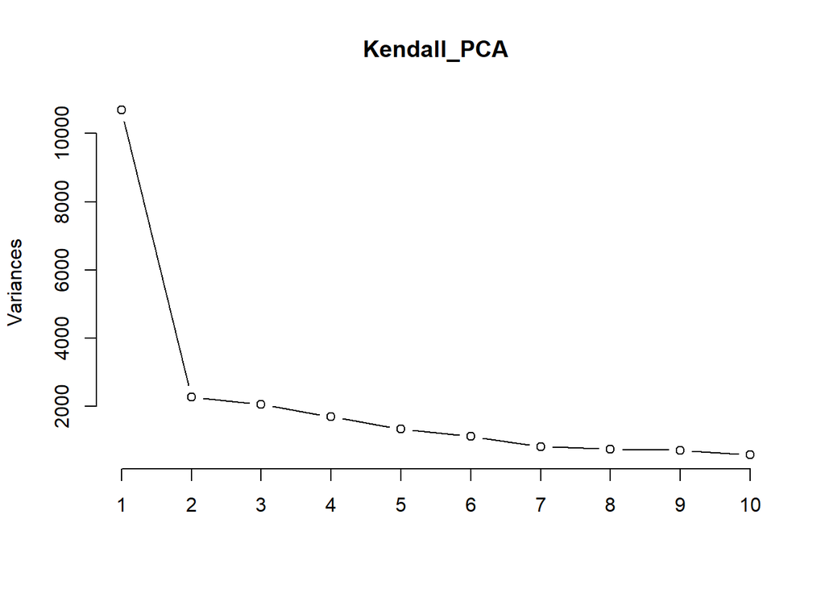

```r
plot(Kendall_PCA, type = "l")
```

# Varaible Reduction: Kendall Rank Correlations - PCA Loadings

```r
#Loadings have variables as rows
KendallPCA_Loadings <- round(Kendall_PCA$rotation [,c(1:5)], 3)
head(KendallPCA_Loadings)
```

```
##              PC1    PC2    PC3    PC4    PC5
## V9_1_Ref  -0.245 -0.249  0.150  0.092  0.091
## V9_3       0.101  0.096 -0.060 -0.051 -0.004
## V9_4       0.102  0.052 -0.039 -0.093 -0.017
## V19_1_Ref -0.181 -0.234  0.174  0.059  0.098
## V26_0     -0.069  0.030 -0.043 -0.176 -0.216
## V26_1_Ref  0.013 -0.002  0.002  0.105  0.127
```

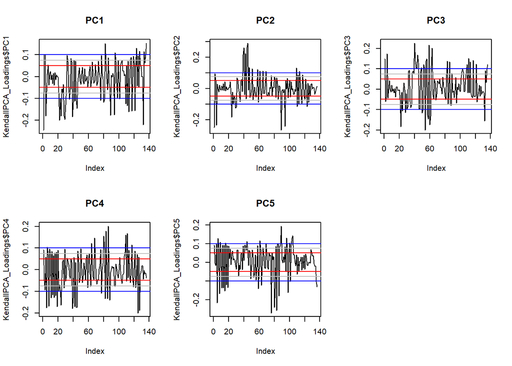

```r
KendallPCA_Loadings <- as.data.frame(KendallPCA_Loadings)
write.csv(KendallPCA_Loadings, file= "KendallPCA_Loadings.csv")

#Plots of Components
#pdf("Loading distribution3.pdf", paper = "USr")
par(mfrow=c(2,3))

plot(KendallPCA_Loadings$PC1, type = "l", main = "PC1")
abline(h=0.05, col="red")
abline(h=-0.05, col="red")
abline(h=0.075, col="grey")
abline(h=-0.075, col="grey")
abline(h=0.1, col="blue")
abline(h=-0.1, col="blue")

plot(KendallPCA_Loadings$PC2, type = "l", main = "PC2")
abline(h=0.05, col="red")
abline(h=-0.05, col="red")
abline(h=0.075, col="grey")
abline(h=-0.075, col="grey")
abline(h=0.1, col="blue")
abline(h=-0.1, col="blue")

plot(KendallPCA_Loadings$PC3, type = "l", main = "PC3")
abline(h=0.05, col="red")
abline(h=-0.05, col="red")
abline(h=0.075, col="grey")
abline(h=-0.075, col="grey")
abline(h=0.1, col="blue")
abline(h=-0.1, col="blue")

plot(KendallPCA_Loadings$PC4, type = "l", main = "PC4")
abline(h=0.05, col="red")
abline(h=-0.05, col="red")
abline(h=0.075, col="grey")
abline(h=-0.075, col="grey")
abline(h=0.1, col="blue")
abline(h=-0.1, col="blue")

plot(KendallPCA_Loadings$PC5, type = "l", main = "PC5")
abline(h=0.05, col="red")
abline(h=-0.05, col="red")
abline(h=0.075, col="grey")
abline(h=-0.075, col="grey")
abline(h=0.1, col="blue")
abline(h=-0.1, col="blue")

#dev.off()
```

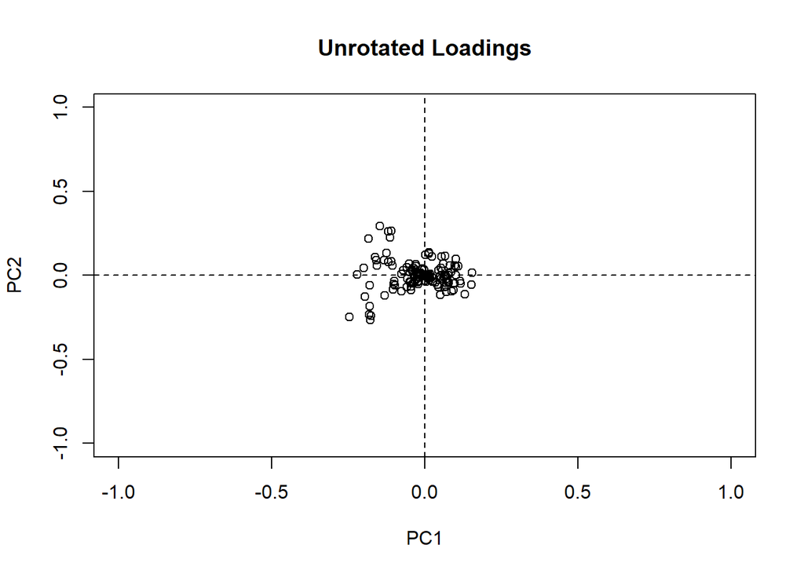

```r
plot(Kendall_PCA$rotation [,c(1:2)], xlim = c(-1, 1), ylim = c(-1, 1), main = "Unrotated Loadings")
abline(v = 0, h = 0, lty = 2)
```

Unfortunately the loadings on these dimensions by different variables is still low, no question loads greater than .3. Hofestede’s dimensions had questions loading well above that as in 0.4 to 0.6 - this is because the questions were all focused on one topic - 10 questions related to workplace goals. From this analysis we see that many are the same as the low variance filter. One way to increase the loading and interprett ability may be to choose only one variable for each question. To make this selection we would need to dig deeper into the non-parametric correlations and how the variables relate to others.

We can try a varimax rotations to see if that helps the loadings of the variables; however, all a roatation does is change the presepective of the data. It doesn’t change how the data has been reduced.

```r
Kendall.Varimax <-varimax(Kendall_PCA$rotation)
#try regressions with national data and then try to reduce the sample to older, educated, males - see if that helps clarify results.
head(Kendall.Varimax$loadings[,c(1:6)])
```

```
##                   PC1           PC2          PC3          PC4         PC5
## V9_1_Ref  -0.74541805 -0.0008315915  0.008497559 -0.011137902 -0.04916863
## V9_3       0.28794605  0.0324907944  0.076812860 -0.068408347  0.12992723
## V9_4       0.15432818 -0.0148410719 -0.121671536 -0.001077164 -0.17334630
## V19_1_Ref -0.40775996 -0.0197626969  0.061136889 -0.021346482  0.07626998
## V26_0      0.00302050  0.0022126920  0.017014204  0.017491081 -0.11726502
## V26_1_Ref  0.02502088  0.0063243825 -0.022173903 -0.026199905  0.04603288
##                    PC6
## V9_1_Ref  -0.013208884
## V9_3      -0.023162224
## V9_4       0.149471859
## V19_1_Ref  0.031452966
## V26_0     -0.032064052
## V26_1_Ref  0.001561283
```

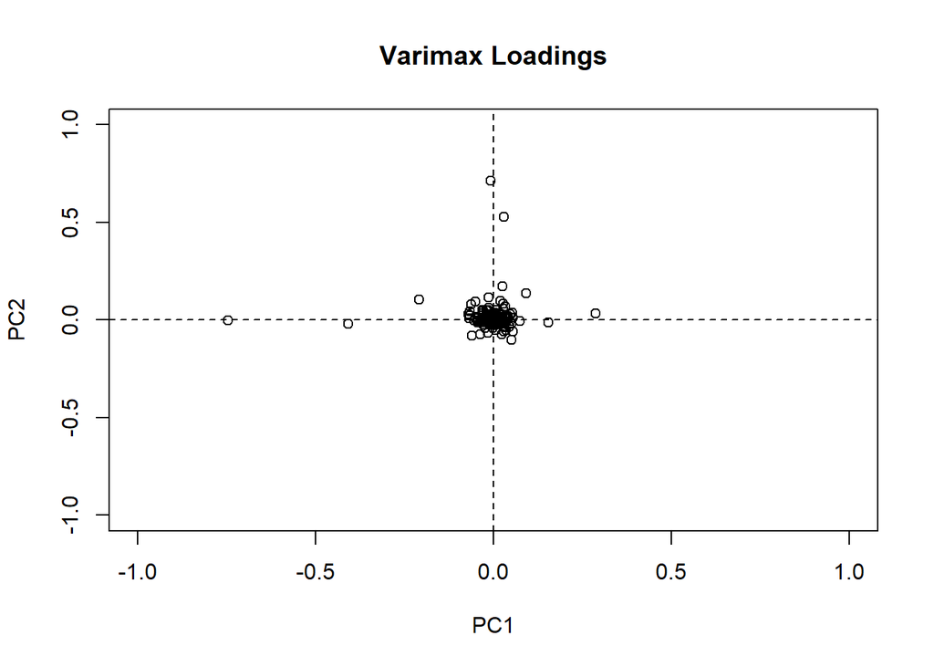

```r
plot(Kendall.Varimax$loadings[,c(1:2)], xlim = c(-1, 1), ylim = c(-1, 1), main = "Varimax Loadings")
abline(v = 0, h = 0, lty = 2)
```

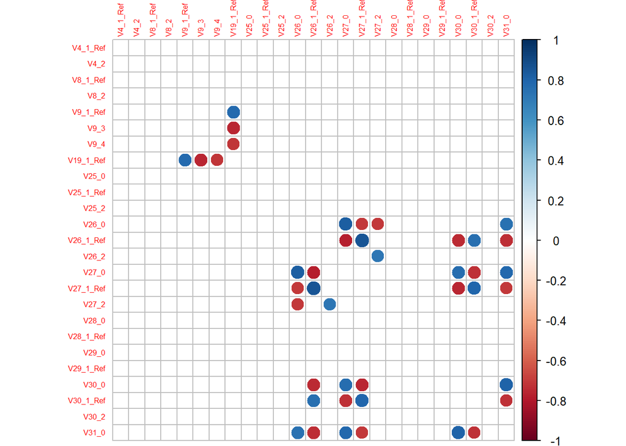

```r
#get rid of the correlations between variables of same questions
for(y in c(1:220)){
Kendall_Correlations_0.7Corr[grep(Eliminate_Kendall[y], colnames(Kendall_Correlations_0.7Corr)),
                              grep(Eliminate_Kendall[y], colnames(Kendall_Correlations_0.7Corr))] = NA
}

library(corrplot)
corrplot(as.matrix(Kendall_Correlations_0.7Corr[c(1:25), c(1:25) ]),
         na.label = "square", na.label.col = "white", tl.cex = 0.5)
```

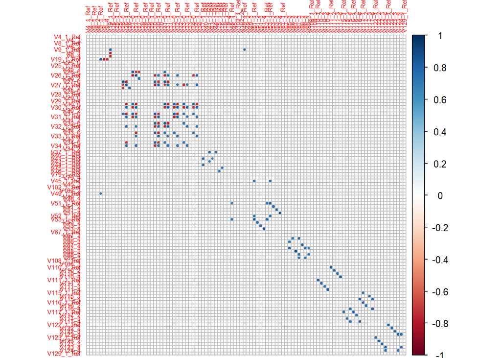

```r
library(corrplot)
corrplot(as.matrix(Kendall_Correlations_0.7Corr[c(1:100), c(1:100) ]),
         na.label = "square", na.label.col = "white", tl.cex = 0.5)
```

It’s interesting to note that there is a clear pattern with respect to how the questions are ordered. This will become more clear when we reduce the number of variables per question to just one.

```r
Kendall.Correlation.Variable.Descriptions <- read.csv("Kendall_Correlation_Variable_Descriptions.csv")

V1_Names <- merge(Sig_Correlations_Clean, Kendall.Correlation.Variable.Descriptions, by.x = "V1", by.y = "VariablestoKeep")

V1_Names <- V1_Names[c("V1", "Description", "R_squared", "V2")]
V2_Names <- merge(V1_Names, Kendall.Correlation.Variable.Descriptions, by.x = "V2", by.y = "VariablestoKeep")
V2_Names <- V2_Names[c("V1", "Description.x", "R_squared", "V2", "Description.y")]
write.csv (V2_Names, "Significant_Correlations_Descriptions.csv")

Reduced_Variables <- read.csv("Reduced_Variables_Kendall.csv")
Reduced_Variables <- as.matrix(Reduced_Variables)
Reduced_Variables_List <- unique(c(Reduced_Variables[,2], Reduced_Variables[,5]))

WVS_Data_Precentages5_Kendall_Clean <- WVS_Data_Precentages5[,Reduced_Variables_List]

Kendall_PCA <- prcomp(WVS_Data_Precentages5_Kendall_Clean)
summary(Kendall_PCA)
```

```
## Importance of components:
##                            PC1     PC2      PC3      PC4     PC5      PC6
## Standard deviation     88.2636 43.2796 35.38296 32.58034 28.6096 26.28946
## Proportion of Variance  0.4568  0.1098  0.07341  0.06224  0.0480  0.04053
## Cumulative Proportion   0.4568  0.5666  0.64006  0.70231  0.7503  0.79083
##                             PC7      PC8      PC9     PC10     PC11
## Standard deviation     23.42444 22.13504 18.76333 18.21053 16.22145
## Proportion of Variance  0.03217  0.02873  0.02064  0.01945  0.01543
## Cumulative Proportion   0.82300  0.85173  0.87238  0.89182  0.90725
##                            PC12     PC13     PC14     PC15     PC16
## Standard deviation     14.56624 14.17989 13.13147 10.80806 10.57266
## Proportion of Variance  0.01244  0.01179  0.01011  0.00685  0.00655
## Cumulative Proportion   0.91969  0.93148  0.94160  0.94845  0.95500
##                           PC17    PC18    PC19    PC20    PC21    PC22
## Standard deviation     9.51467 9.15651 8.62446 7.79389 7.19925 6.74375
## Proportion of Variance 0.00531 0.00492 0.00436 0.00356 0.00304 0.00267
## Cumulative Proportion  0.96031 0.96522 0.96959 0.97315 0.97619 0.97885
##                           PC23    PC24    PC25    PC26    PC27    PC28
## Standard deviation     6.61954 6.44029 5.63161 5.48590 5.26779 4.81418
## Proportion of Variance 0.00257 0.00243 0.00186 0.00176 0.00163 0.00136
## Cumulative Proportion  0.98142 0.98386 0.98572 0.98748 0.98911 0.99047
##                           PC29    PC30    PC31    PC32    PC33    PC34
## Standard deviation     4.68809 4.37498 4.11529 3.83111 3.66178 3.42949
## Proportion of Variance 0.00129 0.00112 0.00099 0.00086 0.00079 0.00069
## Cumulative Proportion  0.99175 0.99288 0.99387 0.99473 0.99552 0.99621
##                           PC35   PC36    PC37    PC38    PC39    PC40
## Standard deviation     3.24931 2.9186 2.74278 2.51924 2.41187 2.37341
## Proportion of Variance 0.00062 0.0005 0.00044 0.00037 0.00034 0.00033
## Cumulative Proportion  0.99683 0.9973 0.99777 0.99814 0.99848 0.99881
##                           PC41   PC42    PC43    PC44   PC45    PC46
## Standard deviation     1.93565 1.8510 1.59656 1.51939 1.3330 1.20835
## Proportion of Variance 0.00022 0.0002 0.00015 0.00014 0.0001 0.00009
## Cumulative Proportion  0.99903 0.9992 0.99938 0.99952 0.9996 0.99971
##                           PC47    PC48    PC49    PC50    PC51    PC52
## Standard deviation     1.18879 1.04001 0.87411 0.80051 0.62880 0.58388
## Proportion of Variance 0.00008 0.00006 0.00004 0.00004 0.00002 0.00002
## Cumulative Proportion  0.99979 0.99985 0.99990 0.99993 0.99996 0.99998
##                           PC53    PC54   PC55      PC56
## Standard deviation     0.44522 0.40478 0.1586 6.315e-15
## Proportion of Variance 0.00001 0.00001 0.0000 0.000e+00
## Cumulative Proportion  0.99999 1.00000 1.0000 1.000e+00
```

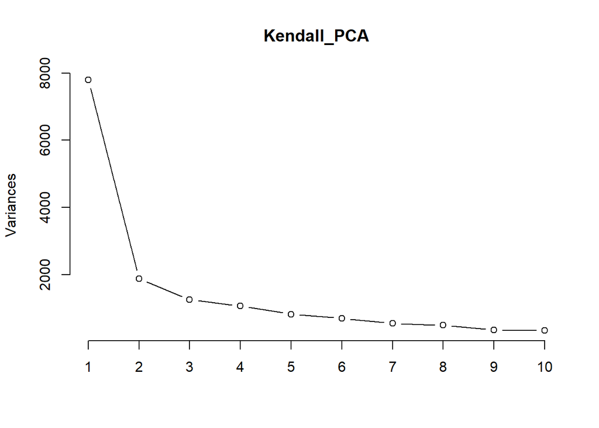

```r
plot(Kendall_PCA, type = "l")
```

```r
Kendall_PCA_Loadings <- Kendall_PCA$rotation

#KendallPCA_Loadings[abs(KendallPCA_Loadings) < 0.1] = NA
#KendallPCA_Loadings_Cleaned <- Kendall_PCA_Loadings[rowSums(is.na(Kendall_PCA_Loadings))!= 5, ]
Kendall_PCA_Loadings_Description <- merge(Kendall_PCA_Loadings,
                                     Kendall.Correlation.Variable.Descriptions, by.x = 0, by.y = "VariablestoKeep" )

Kendall_PCA_Loadings_Description<-  Kendall_PCA_Loadings_Description[,c("Row.names", "Description",
                                                               "PC1", "PC2", "PC3", "PC4", "PC4")]
```

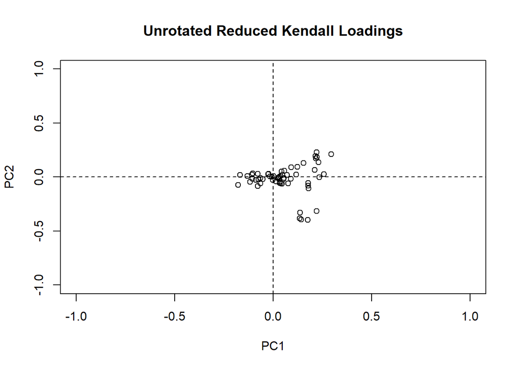

```r
plot(Kendall_PCA_Loadings[,c(1,2)], xlim = c(-1, 1), ylim = c(-1, 1), main = "Unrotated Reduced Kendall Loadings")
abline(v = 0, h = 0, lty = 2)
```

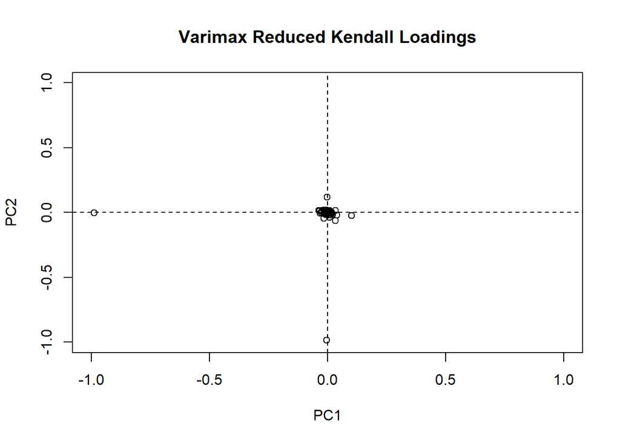

```r
Kendall.Varimax <-varimax(Kendall_PCA$rotation)
#try regressions with national data and then try to reduce the sample to older, educated, males - see if that helps clarify results.
Kendall.Varimax.Loadings <- Kendall.Varimax$loadings[,c(1:6)]
plot(Kendall.Varimax.Loadings[,c(1,2)], xlim = c(-1, 1), ylim = c(-1, 1), main = "Varimax Reduced Kendall Loadings")
abline(v = 0, h = 0, lty = 2)
```

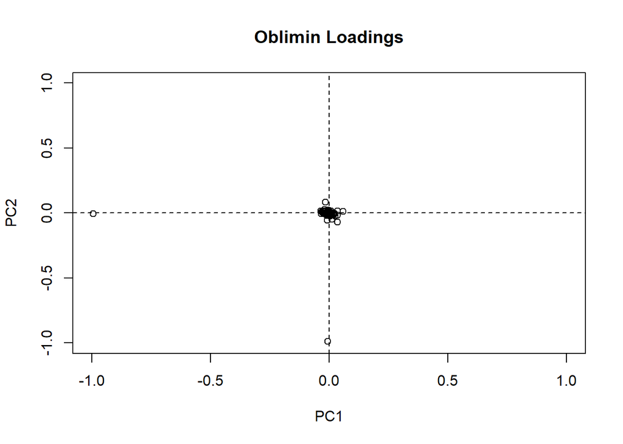

```r
Kendall.Oblimin <- oblimin(Kendall_PCA$rotation)
Kendall.Oblimin.Loadings <- Kendall.Oblimin$loadings

plot(Kendall.Oblimin.Loadings[,c(1,2)], xlim = c(-1, 1), ylim = c(-1, 1), main = "Oblimin Loadings")
abline(v = 0, h = 0, lty = 2)
```

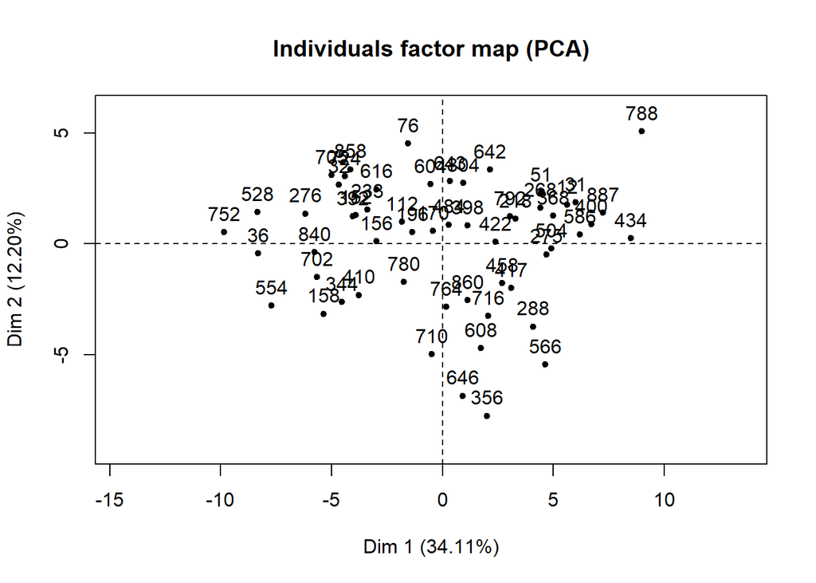

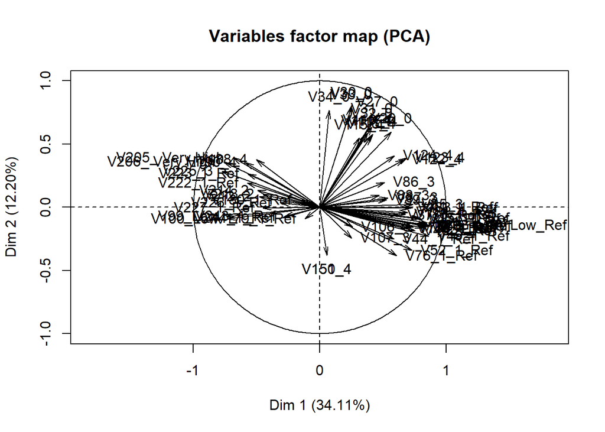

```
## **Results for the Principal Component Analysis (PCA)**
## The analysis was performed on 56 individuals, described by 62 variables
## *The results are available in the following objects:
##
##    name               description
## 1  "$eig"             "eigenvalues"
## 2  "$var"             "results for the variables"
## 3  "$var$coord"       "coord. for the variables"
## 4  "$var$cor"         "correlations variables - dimensions"
## 5  "$var$cos2"        "cos2 for the variables"
## 6  "$var$contrib"     "contributions of the variables"
## 7  "$ind"             "results for the individuals"
## 8  "$ind$coord"       "coord. for the individuals"
## 9  "$ind$cos2"        "cos2 for the individuals"
## 10 "$ind$contrib"     "contributions of the individuals"
## 11 "$call"            "summary statistics"
## 12 "$call$centre"     "mean of the variables"
## 13 "$call$ecart.type" "standard error of the variables"
## 14 "$call$row.w"      "weights for the individuals"
## 15 "$call$col.w"      "weights for the variables"
```

```r
PCA(WVS_Data_Precentages5_Kendall_Clean)
```

```r
KendallPCA_Scores <- Kendall_PCA$x[,c(1:5)]
Named_KendallPCA_Scores <- merge(Country_Names, KendallPCA_Scores, by.y= 0, by.x ="Country.Code", all.y=T)

Renewable_Kendall_Scores <- merge(Renewable_merge, Named_KendallPCA_Scores,
                                   by.x="Country.Name", by.y="Country.Title")
Renewable_Kendall_Scores <- Renewable_Kendall_Scores[,c(1:7, 12:17)]
Renewable_Kendall_Scores<- na.omit(Renewable_Kendall_Scores)
```

### Varaible Reduction:Kendall Filter - Final Data for Regression

This is the dataframe we will use to explore the relationships between renewable electricity production and cultural values.

```r
Final_Data <- Renewable_Kendall_Scores
```

### Varaible Reduction:Kendall Filter - Linear Regression

We will start by testing a linear regression with all 5 principle components and no control, moderator, or mediator variables

```r
fullregression <- lm(log(Final_Data$RE_Generation +1) ~ Final_Data$PC1 + Final_Data$PC2 +
                      Final_Data$PC3 + Final_Data$PC4 + Final_Data$PC5)
summary(fullregression)
```

```
##
## Call:
## lm(formula = log(Final_Data$RE_Generation + 1) ~ Final_Data$PC1 +
##     Final_Data$PC2 + Final_Data$PC3 + Final_Data$PC4 + Final_Data$PC5)
##
## Residuals:
##      Min       1Q   Median       3Q      Max
## -1.24064 -0.49542 -0.04358  0.63602  1.82219
##
## Coefficients:
##                  Estimate Std. Error t value Pr(>|t|)
## (Intercept)     1.1325929  0.1109232  10.211 1.63e-13 ***
## Final_Data$PC1 -0.0076718  0.0012540  -6.118 1.78e-07 ***
## Final_Data$PC2 -0.0032178  0.0025716  -1.251  0.21703
## Final_Data$PC3 -0.0091282  0.0031479  -2.900  0.00566 **
## Final_Data$PC4 -0.0001696  0.0038892  -0.044  0.96540
## Final_Data$PC5 -0.0017446  0.0039669  -0.440  0.66211
## ---
## Signif. codes:  0 '***' 0.001 '**' 0.01 '*' 0.05 '.' 0.1 ' ' 1
##
## Residual standard error: 0.8041 on 47 degrees of freedom
## Multiple R-squared:  0.5003, Adjusted R-squared:  0.4471
## F-statistic: 9.411 on 5 and 47 DF,  p-value: 2.894e-06
```

### Varaible Reduction:Kendall Correlation Filter - Controlling for GDP

```r
GDP_rawdata <- read.csv("World_Bank_GDP_Data.csv")
GDP_Years <- GDP_rawdata[4,]

#remove first 4 rows to bring column headers to top
GDP_data <- GDP_rawdata[c(5:286),]
colnames(GDP_data) <- GDP_Years

#remove all columns except for country names, and 2015 GDP
GDP_data2015 <-GDP_data[,c(1,60)]
colnames(GDP_data2015)<- c("Country.Title", "2015 GDP")

GDP_data_named<-merge(GDP_data2015, Country_Names, by.x= "Country.Title", by.y = "Country.Title")

GDP_Control <- merge(GDP_data_named, Final_Data, by.x = "Country.Title", by.y= "Country.Name")

Control <- GDP_Control$`2015 GDP`/10^9 #down to 53 countries
```

```r
fullregression <- lm(log(Final_Data$RE_Generation +1) ~ Final_Data$PC1 + Final_Data$PC2 +
                      Final_Data$PC3 + Final_Data$PC4 + Final_Data$PC5 + Control)
summary(fullregression)
```

```
##
## Call:
## lm(formula = log(Final_Data$RE_Generation + 1) ~ Final_Data$PC1 +
##     Final_Data$PC2 + Final_Data$PC3 + Final_Data$PC4 + Final_Data$PC5 +
##     Control)
##
## Residuals:
##      Min       1Q   Median       3Q      Max
## -1.16698 -0.49016 -0.04346  0.48166  1.76640
##
## Coefficients:
##                  Estimate Std. Error t value Pr(>|t|)
## (Intercept)     1.128e+00  1.209e-01   9.332 5.38e-12 ***
## Final_Data$PC1 -7.437e-03  1.345e-03  -5.530 1.64e-06 ***
## Final_Data$PC2 -2.849e-03  2.597e-03  -1.097  0.27864
## Final_Data$PC3 -9.160e-03  3.200e-03  -2.862  0.00642 **
## Final_Data$PC4  4.639e-04  3.980e-03   0.117  0.90774
## Final_Data$PC5 -8.877e-04  4.163e-03  -0.213  0.83213
## Control         3.469e-05  4.085e-05   0.849  0.40038
## ---
## Signif. codes:  0 '***' 0.001 '**' 0.01 '*' 0.05 '.' 0.1 ' ' 1
##
## Residual standard error: 0.7997 on 44 degrees of freedom
##   (2 observations deleted due to missingness)
## Multiple R-squared:  0.5153, Adjusted R-squared:  0.4492
## F-statistic: 7.797 on 6 and 44 DF,  p-value: 9.559e-06
```

### Varaible Reduction:Kendall Correlation Filter - Other Controls

```r
Renewable_Resources <- read.csv("Renewable_Resources.csv")

Renewable_Resources<- merge(Renewable_Resources, Final_Data, by.x = "Country.Code", by.y = "Country.Code")

Renewable_Gen<- Renewable_Resources$RE_Generation.x
PC1 <- Renewable_Resources$PC1
PC2 <- Renewable_Resources$PC2
PC3 <- Renewable_Resources$PC3
PC4 <- Renewable_Resources$PC4
PC5 <- Renewable_Resources$PC5
Wind <- Renewable_Resources$Wind
Solar <- as.numeric(Renewable_Resources$Solar)
Policy <- Renewable_Resources$Policy.Target
```

```r
fullregression_resources <- lm(log(Renewable_Gen+1) ~ PC1 + PC2 + PC3 + PC4 + PC5 +
                                 Wind + Solar + Policy)
summary(fullregression_resources)
```

```
##
## Call:
## lm(formula = log(Renewable_Gen + 1) ~ PC1 + PC2 + PC3 + PC4 +
##     PC5 + Wind + Solar + Policy)
##
## Residuals:
##      Min       1Q   Median       3Q      Max
## -1.26175 -0.50979 -0.06243  0.57531  1.86505
##
## Coefficients:
##               Estimate Std. Error t value Pr(>|t|)
## (Intercept)  1.423e+00  2.194e-01   6.485 2.03e-07 ***
## PC1         -5.903e-03  2.106e-03  -2.803  0.00831 **
## PC2          2.471e-04  4.219e-03   0.059  0.95364
## PC3         -5.629e-03  4.304e-03  -1.308  0.19964
## PC4         -2.906e-03  4.832e-03  -0.601  0.55154
## PC5          2.722e-04  5.260e-03   0.052  0.95904
## Wind         7.210e-04  2.363e-03   0.305  0.76215
## Solar       -1.470e-05  1.201e-05  -1.224  0.22928
## Policy       1.118e-01  6.054e-02   1.846  0.07356 .
## ---
## Signif. codes:  0 '***' 0.001 '**' 0.01 '*' 0.05 '.' 0.1 ' ' 1
##
## Residual standard error: 0.8125 on 34 degrees of freedom
##   (10 observations deleted due to missingness)
## Multiple R-squared:  0.5389, Adjusted R-squared:  0.4304
## F-statistic: 4.967 on 8 and 34 DF,  p-value: 0.0003974
```

```r
Wind_Cost_Overruns <- read.csv("Wind_Cost_Overrun_Data.csv")

Wind_Cost_Overruns_Final <- merge(Wind_Cost_Overruns, Country_Names, by.x = "Country", by.y = "Country.Title")
Cost_Performance_Wind <- merge(Wind_Cost_Overruns_Final, GDP_Control, by.x ="Country.Code", by.y = "Country.Code.x")
Cost_Performance_Wind_Resources <- merge(Cost_Performance_Wind, Renewable_Resources,
                                         by.x ="Country.Code", by.y = "Country.Code")

fullregression <- lm(Cost_Performance_Wind$X.Cost.Over.Run.2017 ~ Cost_Performance_Wind$PC1 +
                       Cost_Performance_Wind$PC2 +
                       Cost_Performance_Wind$PC3 +
                       Cost_Performance_Wind$PC4 +
                       Cost_Performance_Wind$PC5 +
                       Cost_Performance_Wind$Offshore +
                       Cost_Performance_Wind_Resources$Wind)

summary(fullregression)
```

```
##
## Call:
## lm(formula = Cost_Performance_Wind$X.Cost.Over.Run.2017 ~ Cost_Performance_Wind$PC1 +
##     Cost_Performance_Wind$PC2 + Cost_Performance_Wind$PC3 + Cost_Performance_Wind$PC4 +
##     Cost_Performance_Wind$PC5 + Cost_Performance_Wind$Offshore +
##     Cost_Performance_Wind_Resources$Wind)
##
## Residuals:
##     Min      1Q  Median      3Q     Max
## -15.438  -5.766  -0.870   3.310  20.255
##
## Coefficients:
##                                       Estimate Std. Error t value Pr(>|t|)
## (Intercept)                          15.823871  23.403885   0.676    0.509
## Cost_Performance_Wind$PC1             0.071593   0.145541   0.492    0.630
## Cost_Performance_Wind$PC2             0.267291   0.378594   0.706    0.491
## Cost_Performance_Wind$PC3             0.297568   0.423448   0.703    0.493
## Cost_Performance_Wind$PC4            -0.298261   0.533682  -0.559    0.584
## Cost_Performance_Wind$PC5            -0.305615   0.468122  -0.653    0.524
## Cost_Performance_Wind$Offshore       17.750000  16.756003   1.059    0.306
## Cost_Performance_Wind_Resources$Wind -0.008066   0.066445  -0.121    0.905
##
## Residual standard error: 11.85 on 15 degrees of freedom
## Multiple R-squared:  0.4766, Adjusted R-squared:  0.2323
## F-statistic: 1.951 on 7 and 15 DF,  p-value: 0.1313
```

While the Kendall analysis seems to be the clearest, in terms of how the variables were reduced to avoid correlations from the structure of the data, the principle components still have very weak loadings and rotations only extract one variables and then cluster the remaining together. This could be do to the agregation method - however, this is the same method that hofested used.

# Non Linear Regression

```r
y = Final_Data$RE_Generation
PC1 = Final_Data$PC1
PC2 = Final_Data$PC2
PC3 = Final_Data$PC3
PC4 = Final_Data$PC4

fit_1 <- nls(y ~ a^PC1 + b^PC2)
#letter c is a function of some type....

cor(y, predict(fit_1))
summary(fit_1)
```

[output not shown]